# Assignment 2

**Loading libraries**

```r
rm(list = ls()) # Clearing the environment
library(tidyverse)
library(magrittr)
library(knitr)
library(FactoMineR)
library(factoextra)
library(GGally)
library(uwot)
```

Setting a seed such that random components does not produce different plots, every time the code runs.

```r
set.seed(42)
```

### Loading the data using read_csv.

```r
Pokemon <- read_csv("https://sds-aau.github.io/SDS-master/00_data/pokemon.csv")
```

# 1)

*Give a brief overview of data, what variables are there, how are the variables scaled and variation of the data columns.*

The *glimpse*() function of **dplyr** provides a nice and compact overview of every column of the dataframe.

```r
Pokemon %>%
  glimpse()
```

```
## Rows: 800
## Columns: 13
## $ Number         <dbl> 1, 2, 3, 3, 4, 5, 6, 6, 6, 7, 8, 9, 9, 10, 11, 12, 1...
## $ Name           <chr> "Bulbasaur", "Ivysaur", "Venusaur", "VenusaurMega Ve...
## $ Type1          <chr> "Grass", "Grass", "Grass", "Grass", "Fire", "Fire", ...
## $ Type2          <chr> "Poison", "Poison", "Poison", "Poison", NA, NA, "Fly...
## $ Total          <dbl> 318, 405, 525, 625, 309, 405, 534, 634, 634, 314, 40...
## $ HitPoints      <dbl> 45, 60, 80, 80, 39, 58, 78, 78, 78, 44, 59, 79, 79, ...
## $ Attack         <dbl> 49, 62, 82, 100, 52, 64, 84, 130, 104, 48, 63, 83, 1...
## $ Defense        <dbl> 49, 63, 83, 123, 43, 58, 78, 111, 78, 65, 80, 100, 1...
## $ SpecialAttack  <dbl> 65, 80, 100, 122, 60, 80, 109, 130, 159, 50, 65, 85,...
## $ SpecialDefense <dbl> 65, 80, 100, 120, 50, 65, 85, 85, 115, 64, 80, 105, ...
## $ Speed          <dbl> 45, 60, 80, 80, 65, 80, 100, 100, 100, 43, 58, 78, 7...
## $ Generation     <dbl> 1, 1, 1, 1, 1, 1, 1, 1, 1, 1, 1, 1, 1, 1, 1, 1, 1, 1...
## $ Legendary      <lgl> FALSE, FALSE, FALSE, FALSE, FALSE, FALSE, FALSE, FAL...
```

It can be seen the dataset contains each Pokémon sorted by their number, and information about the given Pokémon. The type column, *Type1*, is a character vector containing strings describing the primary type of the Pokémon. *Type2* contains the secondary type of the Pokémon, where we see some Pokémon having missing values, suggesting it is not all Pokémon that have a secondary type. The dataset also contains various numerical variables with stats of the given Pokémon. One might have a sneaking suspicion that the *Total* represents the total amount of stats of the given Pokémon, but let’s verify it. This can be done by selecting all the columns with various statpoints, and summing the rows.

```r
StatTotal <- Pokemon %>% # Creating a new vector called StatTotal
  select(6:11) %>% # Selecting every stat i.e. column 6 to 11.
  rowSums()
```

This can be compared to the Total variable in the dataset. A quick way of doing this could be a table displaying the results of the logical test: *The rows in the “Total” column of the Pokemon dataset are all equal to the elements of the StatTotal vector.*

```r
table(Pokemon$Total == StatTotal)
```

```
##
## TRUE
##  800
```

As the table contains 800 rows where the condition is true, and 0 rows where it is false, it can be concluded that the Total column is a sum of the various stats of each Pokémon.

The dataset also includes some categorical variables. The *Generation* variable specifies which generation the Pokémon was introduced to the games. *Generation* ranges between 1-6, which is a much different scale compared to the various stats, and it is therefore necessary to scale before PCA. Finally the column *Legendary* is a logical variable specifying if the Pokémon is legendary or not.

Through **GGally** plots of the distributions of the Pokémon stats can be made. I limit the plots to only use the first three primary types of Pokémon, *grass*, *fire* and *water*, as well as only looking at *attack*, *defense* and *hitpoints*. This is done to simplify the plots.

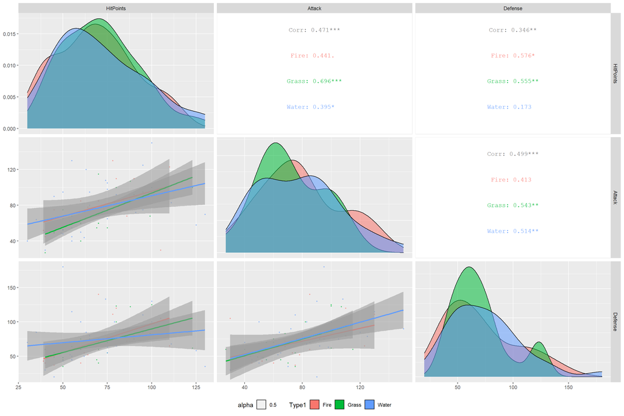

```r
Pokemon %>%
  filter(str_detect(Pokemon$Type1, c("Grass", "Fire", "Water"))) %>% # Only using rows where the Type1 column contains the strings Grass, Fire or Water.
  ggpairs(legend = 1,
          columns = c(6:8), # Selecting attack, defense and hitpoints columns.
          mapping = aes(color = Type1, alpha = 0.5), # Coloring by Pokémon type, and making the distributions see-through.
          lower = list(continuous = wrap("smooth", size=0.5))) +
  theme(legend.position = "bottom")
```

It can be seen that the three types of stats generally follow similar distributions, and that *grass* type Pokémon more often have near-average *attack*, *defense* and *hitpoints* stats.

# 2)

*Execute a PCA analysis on all numerical variables in the dataset. Hint: Don’t forget to scale them first. Use 4 components. What is the cumulative explained variance ratio?*

To compute the principal component analysis, the function *PCA*() from the package **FactoMineR** is used. Within the function the argument **scale.unit** can be used to ensure the variables are scaled prior to the PCA. To ensure numeric columns are used for the PCA, the *select_if* function of **Dplyr** is used along with *is_numeric*. Thus, only columns where *is_numeric* = TRUE are selected for the analysis. Furthermore I chose to remove *Number* and *Generation* to move the analysis away from inter generational differences. *Total* is also dropped since it is a bit redundant when used along with all the other stat variables. For convenience, a dataset only containing numeric variables, with *Number*, *Total* and *Generation* dropped, is made.

```r
Pokemon2 <- Pokemon %>% # Saving the result to a new dataframe.
  select_if(is_numeric) %>% # Only selecting numeric columns.
  select(-Number, -Total, -Generation)
```

Running PCA on the new dataset.

```r
Poke_PCA <- Pokemon2 %>%
  PCA(scale.unit = TRUE, graph = FALSE) # The default graph is deselected.
```

The most efficient number of dimensions can be explored using a Scree plot, which plots the number of dimensions/components against the percentage of explained variance. The plot can be used to distinguish a point where adding more components doesn’t provide sufficient explanatory power. The plot itself is in this case generated by the package **factoextra**, using the *fviz_screeplot*() function.

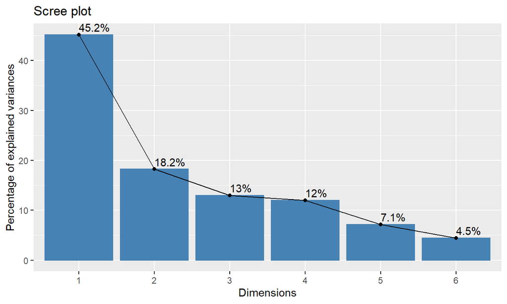

```r
Poke_PCA %>%
  fviz_screeplot(addlabels = TRUE,
                 ncp = 9, # selecting the number of components displayed.
                 ggtheme = theme_gray())
```

The closest thing to an “*elbow*” in the plot, would be at 2 dimensions. The cumulative percentage of variance explained can be found by inspecting the eigenvalues (*eig*) of the PCA.

```r
Poke_PCA$eig %>%
  round(2) %>%  # Rounding the values to the second decimal place.
  as_tibble()
```

```
## # A tibble: 6 x 3
##   eigenvalue `percentage of variance` `cumulative percentage of variance`
##        <dbl>                    <dbl>                               <dbl>
## 1       2.71                    45.2                                 45.2
## 2       1.09                    18.2                                 63.4
## 3       0.78                    13.0                                 76.4
## 4       0.72                    12.0                                 88.4
## 5       0.43                     7.14                                95.6
## 6       0.27                     4.45                               100
```

It can be seen that the first 2 components have an eigenvalue > 1, which would suggest that the majority of the data can be explained by 2 components, where the cumulative percentage of variance explained is at 63.42%. By going from using 2 to 4 components 88.41 % of the variance in the data can be explained, which is an improvement of 24.99 percentagepoints.

From the PCA we can create a biplot, which displays the variable-loadings in the first 2 dimensions. One way of doing it is with the function *fviz_pca_biplot*() from **factoextra**.

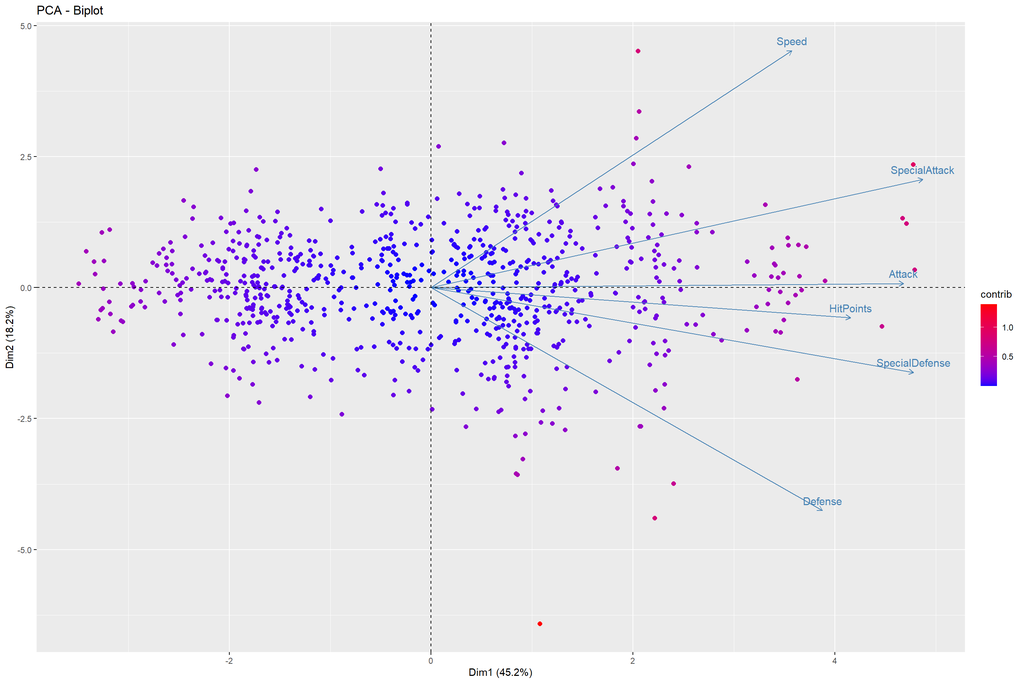

```r
Poke_PCA %>%
  fviz_pca_biplot(col.ind = "contrib", # Colors determined by their contribution.
                  gradient.cols = c("blue","red"), # Color range between green, orange and red.
                  geom = "point", # Adds points to the plot.
                  pointsize = 2, # Increasing the size of the points.
                  ggtheme = theme_gray())
```

Generally the variables all have positive loadings in the first dimension, and a stronger Pokémon will therefore be placed at a higher value on the x-axis. In the second dimension it can be distinguished that a more defensive Pokémon tend to be slower, seeing how *Speed* slopes positively and *Defense* has a negative slope coefficient. A similar, but less significant, effect can be seen with *SpecialAttack* and *SpecialDefense*. It also reveals that a Pokémon with a high *Attack* stat tends to have an almost equivalent, but slightly lower, *Hitpoints* stat.

# 3)

*Use a different dimensionality reduction method (eg. UMAP/NMF) – do the findings differ?*

I will be using the UMAP dimensionality reduction method, through the function *umap*() from the library **uwot**. Like the previous section, the categorical numerical variables are omitted as well as the *Total* variable, by using the Pokemon2 dataframe. The UMAP will assume 4 components, as the previous task.

```r
Poke_UMAP <- Pokemon2 %>%
  umap(n_neighbors = 15,
       n_component = 4, # Specifying that the algorithm uses 4 components.
       metric = "cosine",
       min_dist = 0.01,
       scale = TRUE) # Scaling the variables.
```

To investigate if the findings differ, I will, like the PCA, plot the results for the first two dimensions. This can be accomplished by plotting the first two columns of the results of the UMAP, which in this case is an 800x4 matrix. First the Poke_UMAP is converted from a matrix to a tibble, by *as_tibble*(), to make the *aes* call in the *ggplot* neater. The *ggplot* uses the first column of the data frame (*V1*) for the x-axis and the second column for the y-axis (*V2*). Additionally the points in the scatterplot are colored according to their Pokémon Type 1.

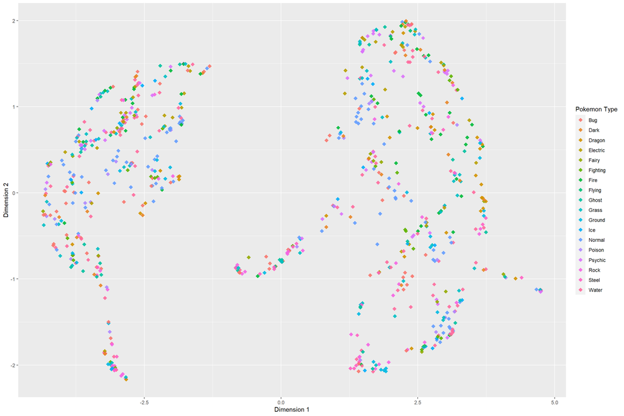

```r
Poke_UMAP %>%
  as_tibble() %>%
  ggplot(aes(x = V1, y = V2, color = Pokemon$Type1)) +
  labs(color='Pokemon Type') + # Custom color label.
  ylab("Dimension 2") + # Custom y label.
  xlab("Dimension 1") + # Custom x label.
  geom_point(shape = 18, alpha = 0.9, size = 3)
```

The UMAP algorithm seems to be able to distinguish between two different groups of Pokémon in the data. The Pokémon are not sorted by their type in any apparent way.

# 4)

*Perform a cluster analysis (KMeans) on all numerical variables (scaled & before PCA). Pick a realistic number of clusters (up to you where the large clusters remain mostly stable).*

The first step of the analysis will be to determine the optimal number of clusters. Initially I will make a screeplot, which displays the total within cluster sum of squares (WSS) for the various numbers of clusters. More clusters will result in a lower total WSS, since the average distance from a point to a clustercenter will decrease, however the marginal effect of another cluster will also decrease. The optimal number of clusters determined by a screeplot will be at the “elbow”, since adding another cluster will result in a significantly lesser change in the Total WSS.

Unlike the previous functions, the scaling is done prior to the function, through the *scale*() function. The screeplot itself is made with *fviz_nbclust*() from **factoextra**.

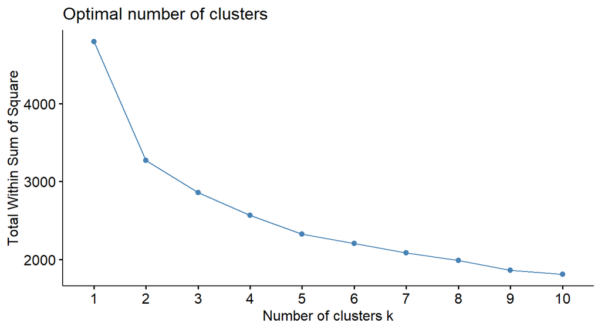

```r
Pokemon2 %>% # Only using numerical variables, and omitting Number, Total and Generation.
  scale() %>% # Normalising the variables.
  fviz_nbclust(kmeans, method = "wss") # Using the method "wss", i.e. Within Sum of Squares.
```

The screeplot shows that going from one cluster to two improves the total WSS greatly, and the closest thing to an “elbow” can be found at 2 clusters, however the WSS is still improved quite a bit by going to 3 clusters. To decide between 2 or 3 clusters, another method is implemented. This is done through the average silhouette width. The silhouette width is a metric of how similar the observations within the clusters are, in comparison to other clusters. A plot of the average silhouette width at different numbers of clusters, can be generated by changing the method in *fviz_nbclust*() to “silhouette”.

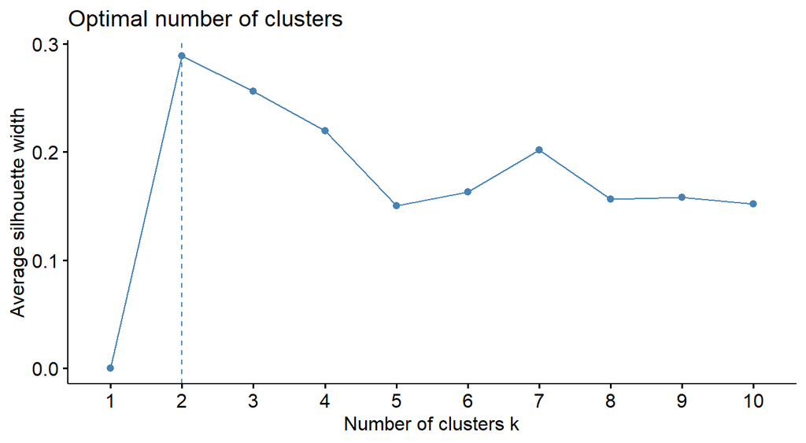

```r
Pokemon2 %>%
  scale() %>%
  fviz_nbclust(kmeans, method = "silhouette")
```

Alike the screeplot, the silhouette analysis also favors using 2 clusters for the analysis. The kmeans analysis will therefore assume 2 clusters.

To assign the observation to clusters, the *kmeans*() function is used, with 20 random starts, as specified by *n_start*.

```r
Poke_KM <- Pokemon2 %>%
  scale() %>% # Scaling the data beforehand.
  kmeans(centers = 2, nstart = 20)  # 2 cluster centers and 20 random starts.

table(Poke_KM$cluster) # Printing a table to investigate how the Pokémon are clustered.
```

```
##
##   1   2
## 376 424
```

376 of the Pokémon ended up in cluster 1 and 424 were assigned to cluster 2. The algorithm was able to divide the Pokémon somewhat evenly, based on their various stats. One possible way of sorting the Pokémon could be to put Pokémon with high stats in one cluster, and Pokémon with low stats in another. To investigate this I construct a new variable, *is_strong*, which contains the result of the logical test: *Does this Pokémon have above average stats?* .

```r
Pokemon %<>% # Pipe from Magrittr, which saves the following work to the specified dataset.
  mutate(is_strong = Total > mean(Pokemon$Total)) # Making a new variable "is_strong". The variable takes the value TRUE if the total stats of the Pokémon is above the mean of the Total column, and FALSE otherwise.
```

It is then possible to check how many of the “strong”/“weak” Pokémon were assigned to each cluster. This is quickly done by creating a table of the new variable vs. the cluster numbers from the *kmeans*() function, since the Pokémon are still sorted in the same order.

```r
table(Pokemon$is_strong,Poke_KM$cluster)
```

```
##
##           1   2
##   FALSE 375   8
##   TRUE    1 416
```

The data seems to create clusters of high-stat Pokémon and low-stat Pokémon, which makes sense since the only information about the Pokémon the algorithm knows, are the stats. The 9 Pokémon in “wrong” clusters would suggest that the sorting is not solely based on the sum of stats, however it is a sufficient explanation for now.

# 5)

*Visualize the first 2 principal components and color the datapoints by cluster.*

The plot of the PCA was made for the second task, so I will reuse the code with some small adjustments. I use the clusters from kmeans, saved to *Poke_KM*, to define groups within the PCA. This is done by the habillage argument, where the clusters in the *Poke_KM* list are used as a factor.

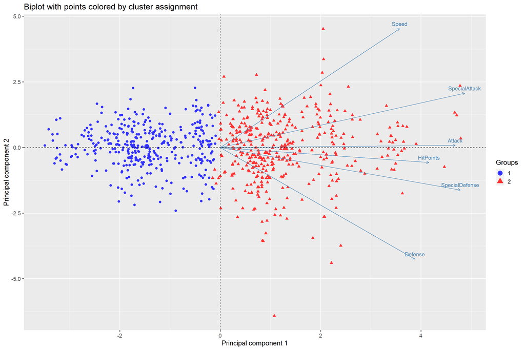

```r
Poke_PCA %>%
  fviz_pca_biplot(geom.ind = "point", pointsize = 2.2,
                  habillage = as.factor(Poke_KM$cluster), # Colors determined by their cluster assignment.
                  ggtheme = theme_gray())+
                  labs(title ="Biplot with points colored by cluster assignment",
                        x = "Principal component 1", y = "Principal component 2")+
                  theme_grey(base_size = 14) + # Changing the font sizing.
                  scale_color_manual(values=c("#3333FF", "#FF3333")) # Adding manual group colors.
```

# 6)

*Inspect the distribution of the variable “Type1” across clusters. Does the algorithm separate the different types of pokemon?*

Initially I save the cluster number to a new variable in the original Pokemon dataset, so I can work within the same dataframe.

```r
Pokemon$Cluster = Poke_KM$cluster
```

Investigating the assignments of Type1 Pokémon in each cluster through a table.

```r
table(Pokemon$Type1, Pokemon$Cluster)
```

```
##
##             1  2
##   Bug      44 25
##   Dark     14 17
##   Dragon    9 23
##   Electric 19 25
##   Fairy     9  8
##   Fighting 12 15
##   Fire     23 29
##   Flying    1  3
##   Ghost    13 19
##   Grass    35 35
##   Ground   16 16
##   Ice      10 14
##   Normal   55 43
##   Poison   14 14
##   Psychic  21 36
##   Rock     20 24
##   Steel     8 19
##   Water    53 59
```

It might be more digestible to display the amount of types per cluster through proportions. This can be done by converting the table to a *prop.table*.

```r
Prop_Cluster <- table(Pokemon$Type1, Pokemon$Cluster) %>% # Saving the table because of fore-shadowing.
  prop.table(margin = 1) %>%  # prop.table with the argument margin = 1, to calculate row-wise proportions.
  round(2) # Rounding the proportions to 2nd decimal.
Prop_Cluster
```

```
##
##               1    2
##   Bug      0.64 0.36
##   Dark     0.45 0.55
##   Dragon   0.28 0.72
##   Electric 0.43 0.57
##   Fairy    0.53 0.47
##   Fighting 0.44 0.56
##   Fire     0.44 0.56
##   Flying   0.25 0.75
##   Ghost    0.41 0.59
##   Grass    0.50 0.50
##   Ground   0.50 0.50
##   Ice      0.42 0.58
##   Normal   0.56 0.44
##   Poison   0.50 0.50
##   Psychic  0.37 0.63
##   Rock     0.45 0.55
##   Steel    0.30 0.70
##   Water    0.47 0.53
```

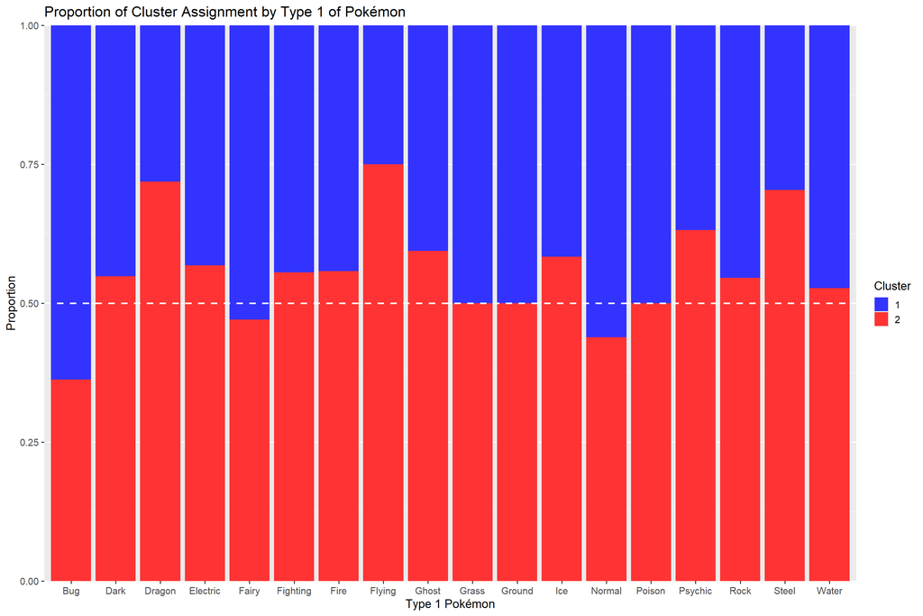

```r
Pokemon %>%
  ggplot() + # Creating a ggplot.
  aes(Type1, fill = factor(Cluster)) + # Type1 along the x-axis and coloring the proportions by cluster assignment.
  geom_bar(position = "fill") + # Makes a barplot and the argument "fill" stacks the bars at the same height, to make the proportions more comparible across types.
  scale_fill_manual(values=c("#3333FF", "#FF3333")) + # Changing the colors.
  labs(title ="Proportion of Cluster Assignment by Type 1 of Pokémon",
       fill='Cluster', x = "Type 1 Pokémon", y = "Proportion") + # A bunch of custom labels.
  theme_grey(base_size = 14) +
  geom_hline(yintercept = 0.5, linetype = "dashed", color = "white", size = 0.9) + # Creating a horizontal line at 50 % on the y-axis.
  scale_y_continuous(expand = c(0, 0), limits = c(0, NA)) # Limiting the y-axis.
```

Thereby we can see which type 1 Pokémon are mostly in cluster 1 and which are mostly in cluster 2. The dashed line can be used as a referencepoint for 50 %. There are no types of Pokémon only assigned to one cluster, so the algorithm has not seperated the different types of Pokémon, which means that no type of Pokémon is exclusively high-stat or low-stat.

To see actual distribution functions I make a plot of the *Total* variable in each cluster, to see how the total stats are distributed for each cluster.

I want a indicator for where the mean of each distribution is. To do that I create a new variable which contains the average of the total stats within the cluster of the given Pokémon, for every Pokémon. The reason for this is the function used to create the vertical lines in the plot, *geom_vline*(), requested an object of length 1 or the length of the dataframe, and I chose to implement the latter.

```r
Pokemon %<>%
  group_by(Cluster) %>% # Grouping the next operation(s) by Cluster.
  mutate(C_mean = mean(Total)) # Creating the new variable: C_mean.
```

I create the density plot using *geom_density*() within a **ggplot** environment. I use cluster as a factor to create two distributions.

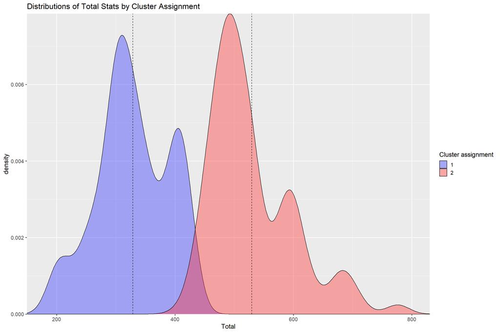

```r
Pokemon %>%
  ggplot(aes(x = Total, fill=factor(Cluster))) +
  geom_density(alpha=.4) + # Making see-through density plots.
  labs(title="Distributions of Total Stats by Cluster Assignment", fill = "Cluster assignment")+
  geom_vline(aes(xintercept = C_mean), linetype="dashed") + # Creating dashed vertical lines to mark the mean of each distribution.
  scale_fill_manual(values=c("#3333FF", "#FF3333")) +
  theme_grey(base_size = 14) +
  scale_x_continuous(expand = c(0, 0), limits = c(150, 830)) + # Limiting the x-axis.
  scale_y_continuous(expand = c(0, 0), limits = c(0, NA)) # Limiting the y-axis.
```

The distributions have a somewhat similar hump to the right side of the mean. One explanation for this could be that when Pokémon evolve, their stats improve by a certain percentage, or atleast in a similar way. I’m unsure if that is the case, but it seems plausible.

# 7)

*Perform a cluster analysis on all numerical variables scaled and AFTER dimensionality reduction and visualize the first 2 principal components.*

For this I choose to use UMAP, and recreate the plot from the 3rd task, with cluster assignments from the kmeans algorithm. The categorical variables are still omitted from the analysis.

I check if 2 is still the most optimal number of clusters, using the same plots as prior tasks. The only difference is that the starting point will be the results of the dimensionality reduction by UMAP, as opposed to the *Pokemon2* dataframe. As the results are similar I will not include the silhuette analysis. I will also not be scaling the coordinates, since they have already been scaled in *umap*().

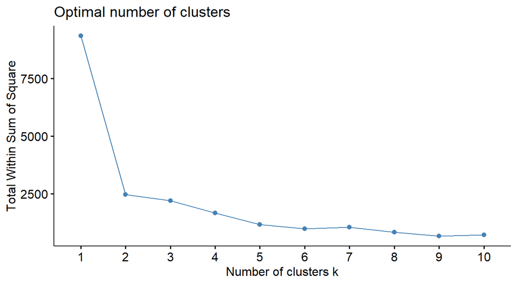

```r
Poke_UMAP %>% # Coordinates after dimensionality reduction by UMAP.
  fviz_nbclust(kmeans, method = "wss") # Screeplot based on minimizing total WSS.
```

The “elbow” in the screeplot is very prominent, heavily suggesting the use of 2 clusters. The scatterplot of the UMAP coordinates (as seen in task 3) reveals why using two clusters reduced the total WSS so greatly, as the points are clearly seperated in two overall groups (atleast in the first two dimensions).

Next I run the kmeans algorithm on the UMAP coordinates, assuming 2 clusters.

```r
Poke_UMAP_KM <- kmeans(Poke_UMAP,centers = 2, nstart = 20)
```

Next I check the UMAP plot, using the cluster assignment as colors, to see if everything went as expected.

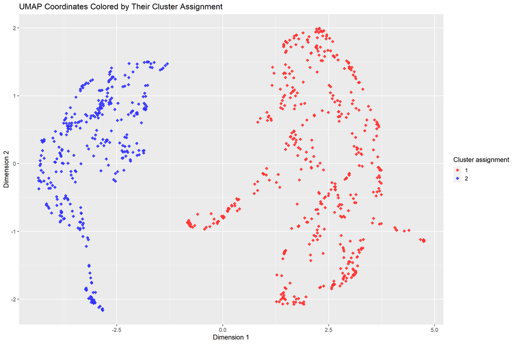

```r
Poke_UMAP %>%
  as_tibble() %>%
  ggplot(aes(x = V1, y = V2, color = as.factor(Poke_UMAP_KM$cluster))) + # Coloring the points by their cluster assignment.
  labs(title="UMAP Coordinates Colored by Their Cluster Assignment",
       color = "Cluster assignment") +
  scale_color_manual(values=c("#FF3333", "#3333FF")) +
  theme_grey(base_size = 14) +
  ylab("Dimension 2") + # Custom y label.
  xlab("Dimension 1") + # Custom x label.
  geom_point(shape = 18, alpha = 0.9, size = 3)
```

The kmeans algorithm did it’s job, and the points are neatly assigned to the most efficient cluster. Let’s see if the UMAP dimensionality reduction changes how the Pokémon are assigned to clusters. Just like task 4 I create a table to check how the “strong”, i.e. high-stat Pokémon, are assigned to the two clusters.

```r
table(Pokemon$is_strong,
      Poke_UMAP_KM$cluster)
```

```
##
##           1   2
##   FALSE  50 333
##   TRUE  416   1
```

This also reveals that the strong Pokémon are assigned to cluster 1, which is the opposite of before. To compare the two clustering, I recode the cluster column, such that 1 and 2 switch places. I save this result to the *Pokemon* dataframe

```r
Pokemon$Cluster_UMAP <- recode(Poke_UMAP_KM$cluster,`1`=2,`2`=1)
```

Let’s verify that the recoding was succesful.

```r
table(Poke_UMAP_KM$cluster, Pokemon$Cluster_UMAP) # Table of the original clustering and the recoded clustering.
```

```
##
##       1   2
##   1   0 466
##   2 334   0
```

Great, cluster 1 assignment is changed to cluster 2 and vice versa. Now we can see if the clustering is the same as without the dimensionality reduction. For this I create a table which displays the logical test: “*The clustering after UMAP is the same as the clustering without dimensionality reduction.*”

```r
table(Pokemon$Cluster_UMAP == Pokemon$Cluster)
```

```
##
## FALSE  TRUE
##    44   756
```

It seems there are 44 Pokémon assigned to a different cluster. Let’s visualize how the assignment changes in the plot of the first 2 principal components. To do this, I yet again reuse my code from earlier, only this time I use the new (recoded) Cluster_UMAP column as my habillage.

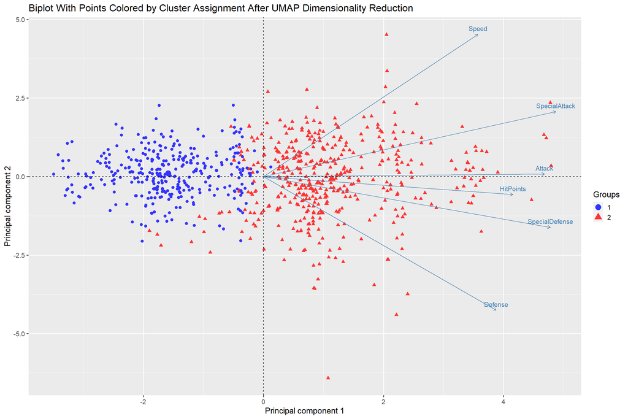

```r
Poke_PCA %>%
  fviz_pca_biplot(geom.ind = "point", pointsize = 2.2,
                  habillage = as.factor(Pokemon$Cluster_UMAP), # Colors determined by their UMAP cluster assignment.
                  ggtheme = theme_gray())+
                  labs(title ="Biplot With Points Colored by Cluster Assignment After UMAP Dimensionality Reduction",
                       x = "Principal component 1",
                       y = "Principal component 2")+
                  theme_grey(base_size = 14) +
                  scale_color_manual(values=c("#3333FF", "#FF3333"))
```

It seems more of the Pokémon that have higher defense/speed, are included in the cluster with the high-stat Pokémon as a result of the dimensionality reduction.

# 8)

*Again, inspect the distribution of the variable “Type 1” across clusters, does it differ from the distribution before dimensionality reduction?*

Like previously it might be valuable to inspect the proportions of Pokémon types assigned to each cluster. I would also like to check the size of the change in proportions, if any. For this I use the proportion table from task 6, which was saved as *Prop_cluster*. However, I will first need to create a similar table from the clustering based on the UMAP coordinates.

```r
Prop_Cluster_UMAP <- table(Pokemon$Type1, Pokemon$Cluster_UMAP) %>%
  prop.table(margin = 1) %>%  # prop.table with the argument margin = 1, to calculate row-wise proportions.
  round(2)
```

Then I bind the two tables together using *cbind*(), which binds the column together in a matrix, along with the difference of the two tables.

```r
Prop_tables_diff <- cbind(Prop_Cluster,
                          Prop_Cluster_UMAP,
                          Prop_Cluster_UMAP-Prop_Cluster) # The difference between the two tables.
```

Next I name the columns and print the result.

```r
colnames(Prop_tables_diff) <- c("Clust1", "Clust2",
                                "UMAP Clust1", "UMAP Clust2",
                                "Diff Clust1", "Diff Clust2") # Assigning new column names.
Prop_tables_diff
```

```
##          Clust1 Clust2 UMAP Clust1 UMAP Clust2 Diff Clust1 Diff Clust2
## Bug        0.64   0.36        0.57        0.43       -0.07        0.07
## Dark       0.45   0.55        0.42        0.58       -0.03        0.03
## Dragon     0.28   0.72        0.28        0.72        0.00        0.00
## Electric   0.43   0.57        0.39        0.61       -0.04        0.04
## Fairy      0.53   0.47        0.47        0.53       -0.06        0.06
## Fighting   0.44   0.56        0.44        0.56        0.00        0.00
## Fire       0.44   0.56        0.38        0.62       -0.06        0.06
## Flying     0.25   0.75        0.25        0.75        0.00        0.00
## Ghost      0.41   0.59        0.38        0.62       -0.03        0.03
## Grass      0.50   0.50        0.46        0.54       -0.04        0.04
## Ground     0.50   0.50        0.41        0.59       -0.09        0.09
## Ice        0.42   0.58        0.38        0.62       -0.04        0.04
## Normal     0.56   0.44        0.47        0.53       -0.09        0.09
## Poison     0.50   0.50        0.50        0.50        0.00        0.00
## Psychic    0.37   0.63        0.35        0.65       -0.02        0.02
## Rock       0.45   0.55        0.39        0.61       -0.06        0.06
## Steel      0.30   0.70        0.19        0.81       -0.11        0.11
## Water      0.47   0.53        0.42        0.58       -0.05        0.05
```

Generally more Pokémon have been included into cluster 2, which can be seen as the cluster for the higher-stat Pokémon.

Like the earlier task, I will also investigate the distributions of the total stats within the two clusters. I reuse the exact code, only changing the fill to the new cluster assignment. To make the dashed line for the mean, I recalculate the cluster mean for the new clusters.

```r
Pokemon %<>%
  group_by(Cluster_UMAP) %>% # Grouping the next operation by the UMAP cluster.
  mutate(C_mean_UMAP = mean(Total)) # Creating the new variable: C_mean_UMAP.
```

Everything is ready for the plot of the distributions.

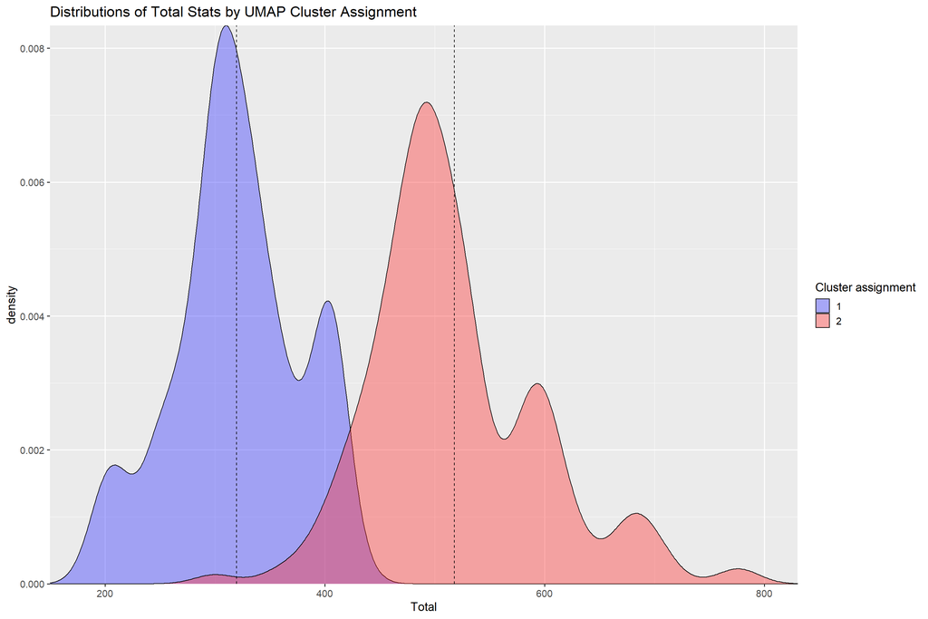

```r
Pokemon %>%
  ggplot(aes(x = Total, fill=factor(Cluster_UMAP))) + # Changing the fill to the UMAP cluster assignment.
  geom_density(alpha=.4) +
  labs(title="Distributions of Total Stats by UMAP Cluster Assignment", fill = "Cluster assignment")+
  geom_vline(aes(xintercept = C_mean_UMAP), linetype="dashed") + # Creating dashed lines to mark the mean of each distribution.
  scale_fill_manual(values=c("#3333FF", "#FF3333")) +
  theme_grey(base_size = 14) +
  scale_x_continuous(expand = c(0, 0), limits = c(150, 830)) +
  scale_y_continuous(expand = c(0, 0), limits = c(0, NA))
```

It is worth noting that both means moved to the left, as the “high-stat” cluster of Pokémon stole more Pokémon from the “low-stat” cluster. This can also be seen from the additional “hump” on the left tail of the cluster 2 distribution. The cluster 1 distribution has also become more centered around it’s mean, and the opposite has happened to the distribution of cluster 2.